# Hotel Bookings - Cancelled Vs Non Cancelled

Benard Omido

2024-06-27

## Objectives:

**1. Predict Customer Cancellations:** Develop a machine learning model to predict whether a customer will cancel their hotel booking or not.

**2. Data Understanding and Exploration:** Perform exploratory data analysis (EDA) to understand the distribution and relationships within the dataset.

**3. Data Preprocessing:** Clean and preprocess the data to make it suitable for modeling.

**4. Model Building and Evaluation:** Fit and evaluate five different machine learning models: K-Nearest Neighbors (KNN), an untuned Decision Tree, a tuned Decision Tree, an untuned Random Forest, and a tuned Random Forest.

**5. Model Selection:** Select the best-performing model based on evaluation metrics.

```r
library(tidyverse)
library(tidymodels)
```

Load the data

```r
hotel_bookings <- read_csv("hotel_bookings.csv")
hotel_bookings
```

```
## # A tibble: 119,390 × 32
##    hotel        is_canceled lead_time arrival_date_year arrival_date_month
##    <chr>              <dbl>     <dbl>             <dbl> <chr>
##  1 Resort Hotel           0       342              2015 July
##  2 Resort Hotel           0       737              2015 July
##  3 Resort Hotel           0         7              2015 July
##  4 Resort Hotel           0        13              2015 July
##  5 Resort Hotel           0        14              2015 July
##  6 Resort Hotel           0        14              2015 July
##  7 Resort Hotel           0         0              2015 July
##  8 Resort Hotel           0         9              2015 July
##  9 Resort Hotel           1        85              2015 July
## 10 Resort Hotel           1        75              2015 July
## # ℹ 119,380 more rows
## # ℹ 27 more variables: arrival_date_week_number <dbl>,
## #   arrival_date_day_of_month <dbl>, stays_in_weekend_nights <dbl>,
## #   stays_in_week_nights <dbl>, adults <dbl>, children <dbl>, babies <dbl>,
## #   meal <chr>, country <chr>, market_segment <chr>,
## #   distribution_channel <chr>, is_repeated_guest <dbl>,
## #   previous_cancellations <dbl>, previous_bookings_not_canceled <dbl>, …
```

```r
glimpse(hotel_bookings)
```

```
## Rows: 119,390
## Columns: 32
## $ hotel                          <chr> "Resort Hotel", "Resort Hotel", "Resort…
## $ is_canceled                    <dbl> 0, 0, 0, 0, 0, 0, 0, 0, 1, 1, 1, 0, 0, …
## $ lead_time                      <dbl> 342, 737, 7, 13, 14, 14, 0, 9, 85, 75, …
## $ arrival_date_year              <dbl> 2015, 2015, 2015, 2015, 2015, 2015, 201…
## $ arrival_date_month             <chr> "July", "July", "July", "July", "July",…
## $ arrival_date_week_number       <dbl> 27, 27, 27, 27, 27, 27, 27, 27, 27, 27,…
## $ arrival_date_day_of_month      <dbl> 1, 1, 1, 1, 1, 1, 1, 1, 1, 1, 1, 1, 1, …
## $ stays_in_weekend_nights        <dbl> 0, 0, 0, 0, 0, 0, 0, 0, 0, 0, 0, 0, 0, …
## $ stays_in_week_nights           <dbl> 0, 0, 1, 1, 2, 2, 2, 2, 3, 3, 4, 4, 4, …
## $ adults                         <dbl> 2, 2, 1, 1, 2, 2, 2, 2, 2, 2, 2, 2, 2, …
## $ children                       <dbl> 0, 0, 0, 0, 0, 0, 0, 0, 0, 0, 0, 0, 0, …
## $ babies                         <dbl> 0, 0, 0, 0, 0, 0, 0, 0, 0, 0, 0, 0, 0, …
## $ meal                           <chr> "BB", "BB", "BB", "BB", "BB", "BB", "BB…
```

[output cut: 19 more lines]

## Description of columns to be used in model building

- lead_time: Longer lead times might increase the likelihood of cancellations.
- stays_in_weekend_nights: Number of weekend nights booked.
- stays_in_week_nights: Number of weekday nights booked.
- adults: Number of adults in the booking.
- children: Number of children in the booking.
- babies: Number of babies in the booking.
- previous_cancellations: Customers with a history of cancellations might be more likely to cancel again.
- previous_bookings_not_canceled: This could provide insight into customer loyalty or reliability.
- booking_changes: Number of changes made to the booking.
- days_in_waiting_list: Longer waiting times might influence the likelihood of cancellations.
- total_of_special_requests: Could indicate the customer’s commitment or specific needs that might impact cancellations.
- required_car_parking_spaces: Might be relevant if lack of parking space availability leads to cancellations.
- hotel: Type or location of the hotel might influence cancellation rates.
- meal: Meal plan booked.
- market_segment: How the booking was made (e.g., direct, corporate).
- distribution_channel: Through which channel the booking was made.
- is_repeated_guest: Repeated guests might have different cancellation patterns.
- reserved_room_type: Type of room reserved.
- assigned_room_type: Type of room assigned.
- deposit_type: Deposit policy could affect cancellations (e.g., no deposit, refundable, non-refundable).
- customer_type: Type of customer (e.g., transient, group).
- adr (Average Daily Rate): Higher prices might correlate with cancellations, especially if customers find better deals elsewhere.

## **Exploratory Analysis**

```r
# Check proportions of cancelled vs non cancelled bookings
hotel_bookings %>%
  count(is_canceled) %>%
  mutate(prop = n / sum(n))
```

```
## # A tibble: 2 × 3
##   is_canceled     n  prop
##         <dbl> <int> <dbl>
## 1           0 75166 0.630
## 2           1 44224 0.370
```

63% of the people did not cancel their bookings while 37% cancelled their bookings

```r
# Convert outcome variable to a factor
hotel_cancellations <- hotel_bookings %>%
  mutate(is_canceled = case_when(is_canceled == 0 ~ "not cancelled",
                                 TRUE ~ "cancelled"),
         is_canceled = factor(is_canceled))

class(hotel_cancellations$is_canceled)
```

```
## [1] "factor"
```

**1. How does the distribution of bookings vary across the hotels?**

```r
hotel_cancellations %>%
  count(hotel)
```

```
## # A tibble: 2 × 2
##   hotel            n
##   <chr>        <int>
## 1 City Hotel   79330
## 2 Resort Hotel 40060
```

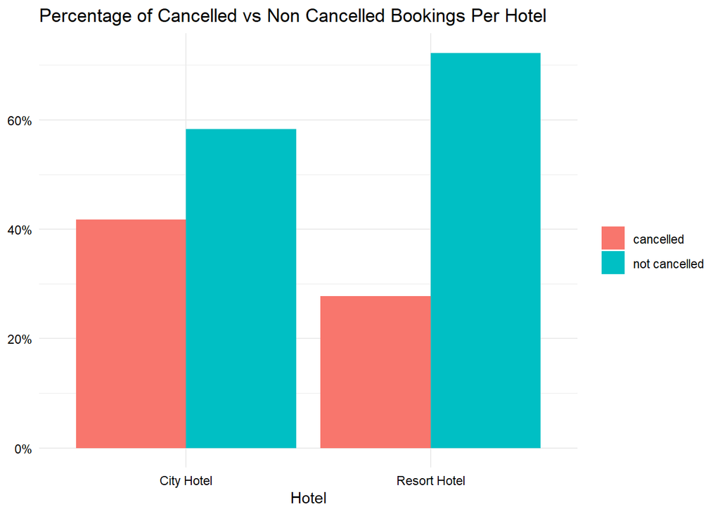

```r
hotel_cancellations %>%
  count(is_canceled, hotel) %>%
  group_by(hotel) %>%
  mutate(prop = n / sum(n)) %>%
  arrange(hotel) %>%
  ggplot(aes(hotel, prop, fill = is_canceled)) +
  geom_col(position = "dodge") +
  labs(x = "Hotel", y = NULL, fill = NULL,
       title = "Percentage of Cancelled vs Non Cancelled Bookings Per Hotel") +
  scale_y_continuous(labels = scales::percent_format()) +
  theme_minimal() +
  theme(axis.text = element_text(color = "black"))
```

Above plot indicate that the City Hotel has a higher percentage of cancelled bookings compared to the Resort Hotel. Specifically, about 41.73% of bookings at the City Hotel are cancelled, while the Resort Hotel experiences a significantly lower cancellation rate of 27.76%.

**2. Does cancellations vary with the number of weekend/week nights booked?**

```r
# Weekend nights booked

hotel_cancellations %>%
  count(stays_in_weekend_nights) %>% head()
```

```
## # A tibble: 6 × 2
##   stays_in_weekend_nights     n
##                     <dbl> <int>
## 1                       0 51998
## 2                       1 30626
## 3                       2 33308
## 4                       3  1259
## 5                       4  1855
## 6                       5    79
```

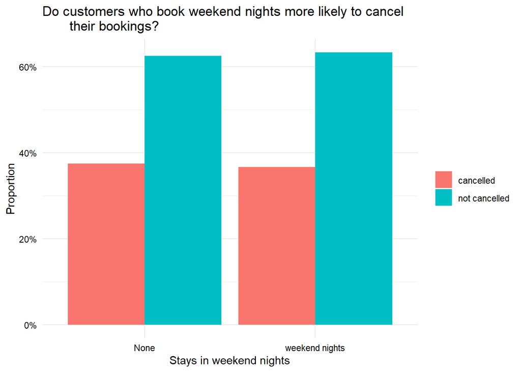

```r
hotel_cancellations %>%
  mutate(stays_in_weekend_nights = case_when(stays_in_weekend_nights > 0 ~ "weekend nights",
                                             TRUE ~ "None")) %>%
  count(stays_in_weekend_nights, is_canceled) %>%
  group_by(stays_in_weekend_nights) %>%
  mutate(prop = n / sum(n)) %>%
  ggplot(aes(stays_in_weekend_nights, prop, fill = is_canceled)) +
  geom_col(position = "dodge") +
  scale_y_continuous(labels = scales::percent_format()) +
  labs(x = "Stays in weekend nights", y = "Proportion", fill = NULL,
       title = "Do customers who book weekend nights more likely to cancel
       their bookings?") +
  theme_minimal() +
  theme(axis.text = element_text(color = "black"))
```

This plot suggest that there is a slight difference in cancellation rates between bookings with and without stays in weekend nights. Focusing on weekend nights only, 36.69% of bookings with weekend nights are cancelled while 63.31% are not.

```r
# Week nights booked

hotel_cancellations %>%
  count(stays_in_week_nights) %>% head()
```

```
## # A tibble: 6 × 2
##   stays_in_week_nights     n
##                  <dbl> <int>
## 1                    0  7645
## 2                    1 30310
## 3                    2 33684
## 4                    3 22258
## 5                    4  9563
## 6                    5 11077
```

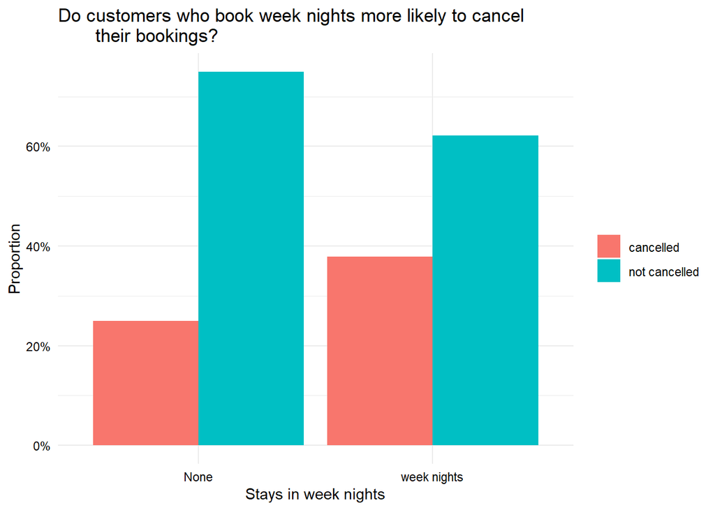

```r
hotel_cancellations%>%
  mutate(stays_in_week_nights = case_when(stays_in_week_nights > 0 ~ "week nights",
                                          TRUE ~ "None")) %>%
  count(stays_in_week_nights, is_canceled) %>%
  group_by(stays_in_week_nights) %>%
  mutate(prop = n / sum(n)) %>%
  ggplot(aes(stays_in_week_nights, prop, fill = is_canceled)) +
  geom_col(position = "dodge") +
  scale_y_continuous(labels = scales::percent_format()) +
  labs(x = "Stays in week nights", y = "Proportion", fill = NULL,
       title = "Do customers who book week nights more likely to cancel
       their bookings?") +
  theme_minimal() +
  theme(axis.text = element_text(color = "black"))
```

There is a notable difference in cancellation rates based on stays in week nights. 25.02% of bookings without week nights are cancelled, compared to a higher cancellation rate of 37.86% for bookings that include week nights. This suggests that bookings with stays during week nights have a significantly higher likelihood of being cancelled compared to those without any week night stays.

```r
hotel_cancellations %>% count(reserved_room_type, is_canceled, sort = TRUE)
```

```
## # A tibble: 19 × 3
##    reserved_room_type is_canceled       n
##    <chr>              <fct>         <int>
##  1 A                  not cancelled 52364
##  2 A                  cancelled     33630
##  3 D                  not cancelled 13099
##  4 D                  cancelled      6102
##  5 E                  not cancelled  4621
##  6 F                  not cancelled  2017
##  7 E                  cancelled      1914
##  8 G                  not cancelled  1331
##  9 F                  cancelled       880
## 10 G                  cancelled       763
## 11 B                  not cancelled   750
## 12 C                  not cancelled   624
## 13 B                  cancelled       368
## 14 H                  not cancelled   356
## 15 C                  cancelled       308
## 16 H                  cancelled       245
## 17 P                  cancelled        12
## 18 L                  not cancelled     4
## 19 L                  cancelled         2
```

```r
hotel_cancellations %>% count(market_segment, is_canceled, sort = TRUE)
```

```
## # A tibble: 15 × 3
##    market_segment is_canceled       n
##    <chr>          <fct>         <int>
##  1 Online TA      not cancelled 35738
##  2 Online TA      cancelled     20739
##  3 Offline TA/TO  not cancelled 15908
##  4 Groups         cancelled     12097
##  5 Direct         not cancelled 10672
##  6 Offline TA/TO  cancelled      8311
##  7 Groups         not cancelled  7714
##  8 Corporate      not cancelled  4303
##  9 Direct         cancelled      1934
## 10 Corporate      cancelled       992
## 11 Complementary  not cancelled   646
## 12 Aviation       not cancelled   185
## 13 Complementary  cancelled        97
## 14 Aviation       cancelled        52
## 15 Undefined      cancelled         2
```

**3. Does cancellations vary with the total price of a room?**

```r
summary(hotel_cancellations$adr)
```

```
##    Min. 1st Qu.  Median    Mean 3rd Qu.    Max.
##   -6.38   69.29   94.58  101.83  126.00 5400.00
```

```r
# The are negative values in the adr column, which is an anomaly

hotel_cancellations %>%
  filter(adr < 0)
```

```
## # A tibble: 1 × 32
##   hotel        is_canceled   lead_time arrival_date_year arrival_date_month
##   <chr>        <fct>             <dbl>             <dbl> <chr>
## 1 Resort Hotel not cancelled       195              2017 March
## # ℹ 27 more variables: arrival_date_week_number <dbl>,
## #   arrival_date_day_of_month <dbl>, stays_in_weekend_nights <dbl>,
## #   stays_in_week_nights <dbl>, adults <dbl>, children <dbl>, babies <dbl>,
## #   meal <chr>, country <chr>, market_segment <chr>,
## #   distribution_channel <chr>, is_repeated_guest <dbl>,
## #   previous_cancellations <dbl>, previous_bookings_not_canceled <dbl>,
## #   reserved_room_type <chr>, assigned_room_type <chr>, …
```

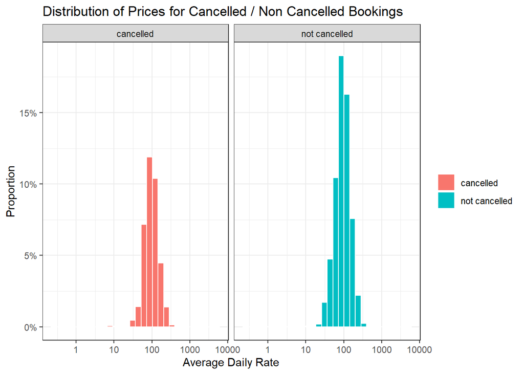

```r
ggplot(hotel_cancellations, aes(adr,
                           fill = is_canceled)) +
  geom_histogram(aes(y =  after_stat(count / sum(count))), color = "white") +
  scale_x_log10() +
  scale_y_continuous(labels = scales::percent_format()) +
  labs(x = "Average Daily Rate", y = "Proportion", fill = NULL,
       title = "Distribution of Prices for Cancelled / Non Cancelled Bookings") +
  facet_wrap(~is_canceled) +
  theme_bw()
```

The distribution of the average daily rate (ADR) for both cancelled and non-cancelled bookings shows some similarities and differences. The most common ADR for both groups is around 100. However, non-cancelled bookings have a higher peak at this rate compared to cancelled bookings. This indicates that while the overall price distribution is similar, bookings at or around this common ADR of 100 are more likely to be non-cancelled.

**4. How does the distribution of hotel cancellations vary by month in each hotel?**

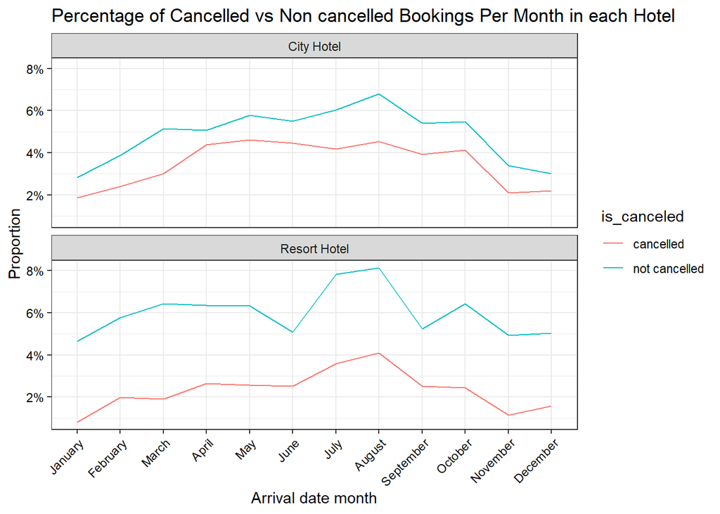

```r
hotel_cancellations %>%
  mutate(arrival_date_month = factor(arrival_date_month,
                                     levels = month.name)) %>%
  count(arrival_date_month, is_canceled, hotel) %>%
  group_by(hotel) %>%
  mutate(prop = n / sum(n)) %>%
  ggplot(aes(arrival_date_month, prop, group = is_canceled)) +
  geom_line(aes(color = is_canceled)) +
  facet_wrap(~hotel, nrow = 2) +
  labs(x = "Arrival date month", y = "Proportion", fill = NULL,
       title = "Percentage of Cancelled vs Non cancelled Bookings Per Month in each Hotel") +
  scale_y_continuous(labels = scales::percent_format()) +
  theme_bw() +
  theme(axis.text = element_text(color = "black"),
        axis.text.x = element_text(angle = 45, hjust = 1))
```

**5. Do customers who require car parking spaces more likely to cancel their bookings?**

```r
hotel_cancellations %>%
  count(required_car_parking_spaces)
```

```
## # A tibble: 5 × 2
##   required_car_parking_spaces      n
##                         <dbl>  <int>
## 1                           0 111974
## 2                           1   7383
## 3                           2     28
## 4                           3      3
## 5                           8      2
```

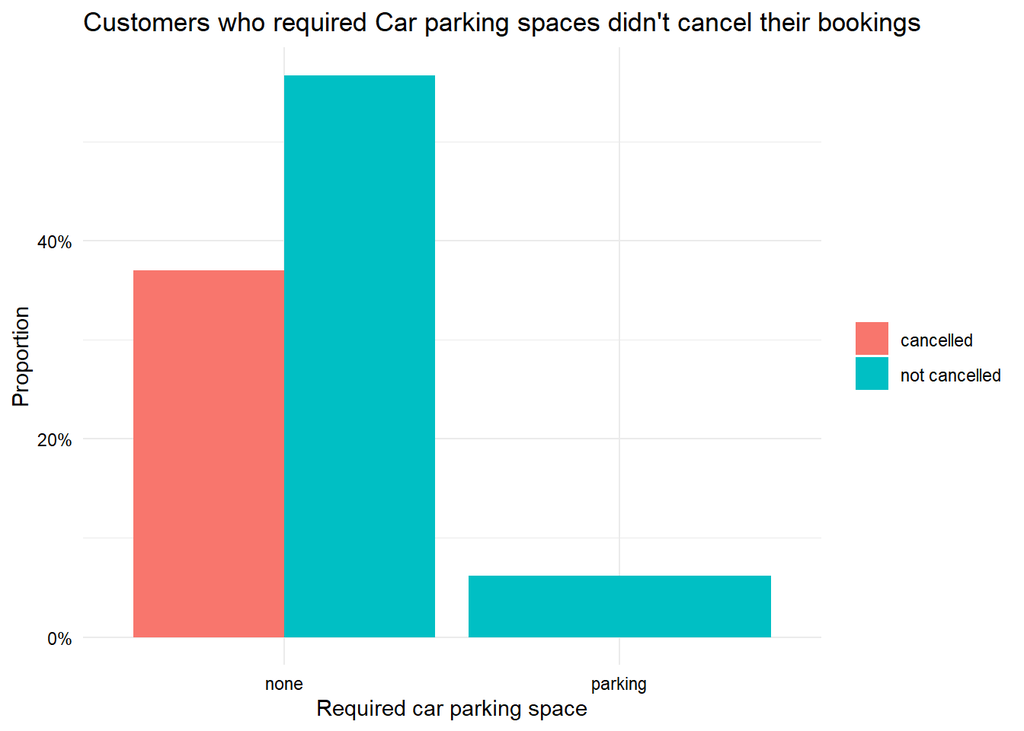

```r
hotel_cancellations %>%
  mutate(required_car_parking_spaces = case_when(required_car_parking_spaces > 0 ~ "parking",
                                          TRUE ~ "none")) %>%
  count(is_canceled ,required_car_parking_spaces) %>%
  arrange(required_car_parking_spaces) %>%
  mutate(prop = n / sum(n)) %>%
  ggplot(aes(required_car_parking_spaces, prop, fill = is_canceled)) +
  geom_col(position = "dodge") +
  scale_y_continuous(labels = scales::percent_format()) +
  labs(x = "Required car parking space", y = "Proportion", fill = NULL,
       title = "Customers who required Car parking spaces didn't cancel their bookings")+
  theme_minimal() +
  theme(axis.text = element_text(color = "black"))
```

Customers who required car parking spaces didn’t cancel their bookings

**6. Does cancellations vary with whether one has children?**

```r
hotel_cancellations %>%
  mutate(children = case_when(children + babies > 0 ~ "children",
                              TRUE ~ "none")) %>%
  count(children, is_canceled)
```

```
## # A tibble: 4 × 3
##   children is_canceled       n
##   <chr>    <fct>         <int>
## 1 children cancelled      3259
## 2 children not cancelled  6073
## 3 none     cancelled     40965
## 4 none     not cancelled 69093
```

**Preparing the data set**

```r
hotel_cancellations <- hotel_cancellations %>%
  mutate(is_repeated_guest = factor(is_repeated_guest),
         children = case_when(children + babies > 0 ~ "children",
                              TRUE ~ "none"),
         required_car_parking_spaces = case_when(required_car_parking_spaces > 0 ~ "parking",
                                                 TRUE ~ "none")
         ) %>%
  select(-c(arrival_date_year, arrival_date_week_number, arrival_date_week_number,
            country, agent, company, reservation_status, reservation_status_date, babies)) %>%
  mutate_if(is.character, factor)

hotel_cancellations
```

```
## # A tibble: 119,390 × 24
##    hotel        is_canceled  lead_time arrival_date_month arrival_date_day_of_…¹
##    <fct>        <fct>            <dbl> <fct>                               <dbl>
##  1 Resort Hotel not cancell…       342 July                                    1
##  2 Resort Hotel not cancell…       737 July                                    1
##  3 Resort Hotel not cancell…         7 July                                    1
##  4 Resort Hotel not cancell…        13 July                                    1
##  5 Resort Hotel not cancell…        14 July                                    1
##  6 Resort Hotel not cancell…        14 July                                    1
##  7 Resort Hotel not cancell…         0 July                                    1
##  8 Resort Hotel not cancell…         9 July                                    1
##  9 Resort Hotel cancelled           85 July                                    1
## 10 Resort Hotel cancelled           75 July                                    1
## # ℹ 119,380 more rows
## # ℹ abbreviated name: ¹arrival_date_day_of_month
## # ℹ 19 more variables: stays_in_weekend_nights <dbl>,
## #   stays_in_week_nights <dbl>, adults <dbl>, children <fct>, meal <fct>,
## #   market_segment <fct>, distribution_channel <fct>, is_repeated_guest <fct>,
## #   previous_cancellations <dbl>, previous_bookings_not_canceled <dbl>,
## #   reserved_room_type <fct>, assigned_room_type <fct>, …
```

```r
# In this project, I only use a sample of the whole data set to illustrate the model building process, tuning, and model selection
set.seed(567)

hotel_cancellations <- hotel_cancellations %>%
  slice_sample(n = 10000, replace = FALSE)

hotel_cancellations
```

```
## # A tibble: 10,000 × 24
##    hotel        is_canceled  lead_time arrival_date_month arrival_date_day_of_…¹
##    <fct>        <fct>            <dbl> <fct>                               <dbl>
##  1 City Hotel   cancelled           20 September                              24
##  2 Resort Hotel not cancell…         3 January                                13
##  3 Resort Hotel not cancell…       156 July                                   31
##  4 City Hotel   not cancell…         2 October                                 7
##  5 Resort Hotel not cancell…        13 April                                   9
##  6 City Hotel   not cancell…         1 April                                   1
##  7 Resort Hotel not cancell…         4 July                                   23
##  8 City Hotel   cancelled           87 June                                    3
##  9 City Hotel   cancelled           72 April                                   3
## 10 City Hotel   not cancell…       115 February                               27
## # ℹ 9,990 more rows
## # ℹ abbreviated name: ¹arrival_date_day_of_month
## # ℹ 19 more variables: stays_in_weekend_nights <dbl>,
## #   stays_in_week_nights <dbl>, adults <dbl>, children <fct>, meal <fct>,
## #   market_segment <fct>, distribution_channel <fct>, is_repeated_guest <fct>,
## #   previous_cancellations <dbl>, previous_bookings_not_canceled <dbl>,
## #   reserved_room_type <fct>, assigned_room_type <fct>, …
```

### **Build a model to predict whether a customer will cancel the booking or not**

Split the data into training and testing sets

```r
hotel_cancellations %>%
  count(is_canceled)
```

```
## # A tibble: 2 × 2
##   is_canceled       n
##   <fct>         <int>
## 1 cancelled      3673
## 2 not cancelled  6327
```

```r
set.seed(123)

hotel_splits <- initial_split(hotel_cancellations, strata = is_canceled)
hotel_splits
```

```
## <Training/Testing/Total>
## <7499/2501/10000>
```

```r
hotel_train <- training(hotel_splits)
hotel_test <- testing(hotel_splits)

hotel_train
```

```
## # A tibble: 7,499 × 24
##    hotel        is_canceled lead_time arrival_date_month arrival_date_day_of_m…¹
##    <fct>        <fct>           <dbl> <fct>                                <dbl>
##  1 City Hotel   cancelled          20 September                               24
##  2 City Hotel   cancelled          87 June                                     3
##  3 City Hotel   cancelled          53 January                                 19
##  4 Resort Hotel cancelled          38 August                                  10
##  5 City Hotel   cancelled         273 September                               30
##  6 City Hotel   cancelled         218 August                                  21
##  7 City Hotel   cancelled         272 October                                 22
##  8 City Hotel   cancelled         157 August                                  19
##  9 City Hotel   cancelled         313 August                                  26
## 10 City Hotel   cancelled         160 December                                30
## # ℹ 7,489 more rows
## # ℹ abbreviated name: ¹arrival_date_day_of_month
## # ℹ 19 more variables: stays_in_weekend_nights <dbl>,
## #   stays_in_week_nights <dbl>, adults <dbl>, children <fct>, meal <fct>,
## #   market_segment <fct>, distribution_channel <fct>, is_repeated_guest <fct>,
## #   previous_cancellations <dbl>, previous_bookings_not_canceled <dbl>,
## #   reserved_room_type <fct>, assigned_room_type <fct>, …
```

```r
hotel_test
```

```
## # A tibble: 2,501 × 24
##    hotel        is_canceled  lead_time arrival_date_month arrival_date_day_of_…¹
##    <fct>        <fct>            <dbl> <fct>                               <dbl>
##  1 Resort Hotel not cancell…         4 July                                   23
##  2 City Hotel   cancelled           72 April                                   3
##  3 Resort Hotel not cancell…       272 May                                     1
##  4 City Hotel   not cancell…       188 September                              26
##  5 City Hotel   cancelled          128 July                                    7
##  6 City Hotel   not cancell…         8 May                                    25
##  7 Resort Hotel not cancell…       175 April                                  29
##  8 City Hotel   not cancell…        22 November                               27
##  9 City Hotel   not cancell…       208 August                                  2
## 10 City Hotel   not cancell…         1 January                                 2
## # ℹ 2,491 more rows
## # ℹ abbreviated name: ¹arrival_date_day_of_month
## # ℹ 19 more variables: stays_in_weekend_nights <dbl>,
## #   stays_in_week_nights <dbl>, adults <dbl>, children <fct>, meal <fct>,
## #   market_segment <fct>, distribution_channel <fct>, is_repeated_guest <fct>,
## #   previous_cancellations <dbl>, previous_bookings_not_canceled <dbl>,
## #   reserved_room_type <fct>, assigned_room_type <fct>, …
```

Create a recipe

```r
library(themis)

hotel_train %>%
  count(is_canceled)
```

```
## # A tibble: 2 × 2
##   is_canceled       n
##   <fct>         <int>
## 1 cancelled      2754
## 2 not cancelled  4745
```

```r
hotel_recipe <- recipe(is_canceled ~ ., data = hotel_train) %>%
  step_downsample(is_canceled) %>%   #Take care of class imbalance first
  step_normalize(all_numeric_predictors()) %>%      #Normalize all predictors
  step_dummy(all_nominal_predictors())   #Convert all factors to dummy variables

hotel_recipe

hotel_preproc <- prep(hotel_recipe)
hotel_preproc

#View the transformed data

bake(hotel_preproc, new_data = NULL)
```

```
## # A tibble: 5,508 × 67
##    lead_time arrival_date_day_of_m…¹ stays_in_weekend_nig…² stays_in_week_nights
##        <dbl>                   <dbl>                  <dbl>                <dbl>
##  1    -0.846                   0.937                 1.08                 -0.278
##  2    -0.239                  -1.47                  1.08                 -0.278
##  3    -0.547                   0.364                -0.935                 0.255
##  4    -0.683                  -0.669                 1.08                  1.32
##  5     1.45                    1.63                  0.0705               -0.278
##  6     0.949                   0.593                 0.0705                0.789
##  7     1.44                    0.708                -0.935                 0.255
##  8     0.396                   0.364                 1.08                  0.255
##  9     1.81                    1.17                 -0.935                -0.278
## 10     0.423                   1.63                 -0.935                 0.255
## # ℹ 5,498 more rows
## # ℹ abbreviated names: ¹arrival_date_day_of_month, ²stays_in_weekend_nights
## # ℹ 63 more variables: adults <dbl>, previous_cancellations <dbl>,
## #   previous_bookings_not_canceled <dbl>, booking_changes <dbl>,
## #   days_in_waiting_list <dbl>, adr <dbl>, total_of_special_requests <dbl>,
## #   is_canceled <fct>, hotel_Resort.Hotel <dbl>,
## #   arrival_date_month_August <dbl>, arrival_date_month_December <dbl>, …
```

Create cross validation folds

```r
# Cross validation fold to evaluate model performance

set.seed(234)
hotel_folds <- vfold_cv(hotel_train, strata = is_canceled)
hotel_folds
```

```
## #  10-fold cross-validation using stratification
## # A tibble: 10 × 2
##    splits             id
##    <list>             <chr>
##  1 <split [6748/751]> Fold01
##  2 <split [6748/751]> Fold02
##  3 <split [6748/751]> Fold03
##  4 <split [6748/751]> Fold04
##  5 <split [6749/750]> Fold05
##  6 <split [6750/749]> Fold06
##  7 <split [6750/749]> Fold07
##  8 <split [6750/749]> Fold08
##  9 <split [6750/749]> Fold09
## 10 <split [6750/749]> Fold10
```

```r
#To save predictions from the assessment set

keep_pred <- control_resamples(save_pred = TRUE, save_workflow = TRUE)
keep_pred
```

```
## grid/resamples control object
```

### **Build Models**

```r
# knn model

library(kknn)

knn_model <- nearest_neighbor() %>%
  set_engine("kknn") %>%
  set_mode("classification")

knn_model
```

```
## K-Nearest Neighbor Model Specification (classification)
##
## Computational engine: kknn
```

```r
# Decision tree

tree_model <- decision_tree() %>%
  set_engine("rpart") %>%
  set_mode("classification")

tree_model
```

```
## Decision Tree Model Specification (classification)
##
## Computational engine: rpart
```

```r
# Tuned decision tree model to check if it improves the performance

tree_model_tune <- decision_tree(
  cost_complexity = tune(),
  tree_depth = tune(),
  min_n = tune()
) %>%
  set_engine("rpart") %>%
  set_mode("classification")

tree_model_tune
```

```
## Decision Tree Model Specification (classification)
##
## Main Arguments:
##   cost_complexity = tune()
##   tree_depth = tune()
##   min_n = tune()
##
## Computational engine: rpart
```

```r
# Random forest model

rf_model <- rand_forest() %>%
  set_engine("ranger", importance = "impurity") %>%
  set_mode("classification")

rf_model
```

```
## Random Forest Model Specification (classification)
##
## Engine-Specific Arguments:
##   importance = impurity
##
## Computational engine: ranger
```

```r
# Tuned Random forest model

rf_model_tune <- rand_forest(mtry = tune(),
                        trees = 1000,
                        min_n = tune()) %>%
  set_engine("ranger", importance = "impurity") %>%
  set_mode("classification")

rf_model_tune
```

```
## Random Forest Model Specification (classification)
##
## Main Arguments:
##   mtry = tune()
##   trees = 1000
##   min_n = tune()
##
## Engine-Specific Arguments:
##   importance = impurity
##
## Computational engine: ranger
```

```r
# Create a list to store the 3 models

mdls <- list(
  knn = knn_model,
  tree_mdl = tree_model,
  tree_mdl_tune = tree_model_tune,
  rf_mdl = rf_model,
  rf_mdl_tune = rf_model_tune
)


# Workflow set
booking_models <- workflow_set(
  preproc = list(hotel_recipe),
  models = mdls
)

booking_models
```

```
## # A workflow set/tibble: 5 × 4
##   wflow_id             info             option    result
##   <chr>                <list>           <list>    <list>
## 1 recipe_knn           <tibble [1 × 4]> <opts[0]> <list [0]>
## 2 recipe_tree_mdl      <tibble [1 × 4]> <opts[0]> <list [0]>
## 3 recipe_tree_mdl_tune <tibble [1 × 4]> <opts[0]> <list [0]>
## 4 recipe_rf_mdl        <tibble [1 × 4]> <opts[0]> <list [0]>
## 5 recipe_rf_mdl_tune   <tibble [1 × 4]> <opts[0]> <list [0]>
```

```r
doParallel::registerDoParallel()
```

Fit the models using workflow_map

```r
set.seed(345)

booking_res <- workflow_map(booking_models,
             "tune_grid",
             resamples = hotel_folds,
             metrics = metric_set(roc_auc, accuracy, sensitivity, specificity))

booking_res
```

```
## # A workflow set/tibble: 5 × 4
##   wflow_id             info             option    result
##   <chr>                <list>           <list>    <list>
## 1 recipe_knn           <tibble [1 × 4]> <opts[2]> <rsmp[+]>
## 2 recipe_tree_mdl      <tibble [1 × 4]> <opts[2]> <rsmp[+]>
## 3 recipe_tree_mdl_tune <tibble [1 × 4]> <opts[2]> <tune[+]>
## 4 recipe_rf_mdl        <tibble [1 × 4]> <opts[2]> <rsmp[+]>
## 5 recipe_rf_mdl_tune   <tibble [1 × 4]> <opts[2]> <tune[+]>
```

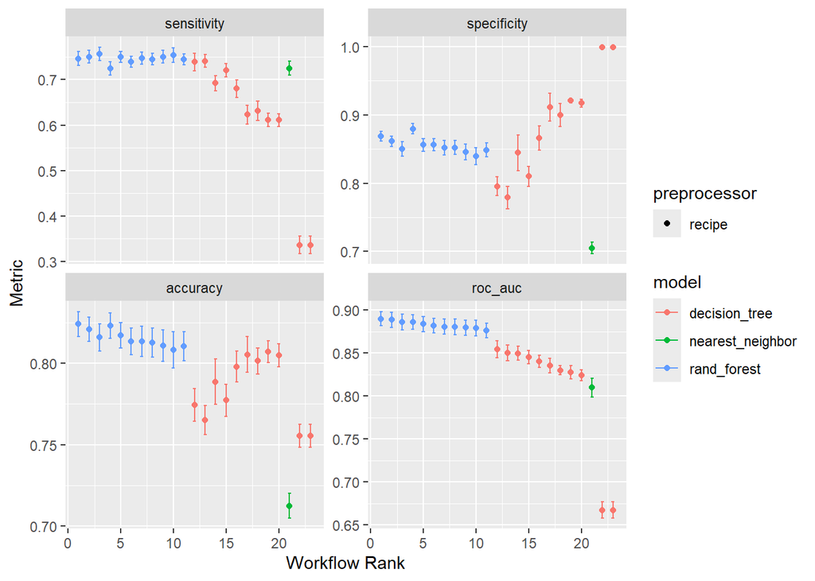

```r
autoplot(booking_res)
```

```r
rank_results(booking_res, rank_metric = "roc_auc")
```

```
## # A tibble: 92 × 9
##    wflow_id         .config .metric  mean std_err     n preprocessor model  rank
##    <chr>            <chr>   <chr>   <dbl>   <dbl> <int> <chr>        <chr> <int>
##  1 recipe_rf_mdl    Prepro… accura… 0.824 0.00470    10 recipe       rand…     1
##  2 recipe_rf_mdl    Prepro… roc_auc 0.890 0.00512    10 recipe       rand…     1
##  3 recipe_rf_mdl    Prepro… sensit… 0.747 0.00942    10 recipe       rand…     1
##  4 recipe_rf_mdl    Prepro… specif… 0.869 0.00446    10 recipe       rand…     1
##  5 recipe_rf_mdl_t… Prepro… accura… 0.821 0.00451    10 recipe       rand…     2
##  6 recipe_rf_mdl_t… Prepro… roc_auc 0.889 0.00522    10 recipe       rand…     2
##  7 recipe_rf_mdl_t… Prepro… sensit… 0.751 0.00834    10 recipe       rand…     2
##  8 recipe_rf_mdl_t… Prepro… specif… 0.861 0.00465    10 recipe       rand…     2
##  9 recipe_rf_mdl_t… Prepro… accura… 0.816 0.00506    10 recipe       rand…     3
## 10 recipe_rf_mdl_t… Prepro… roc_auc 0.886 0.00553    10 recipe       rand…     3
## # ℹ 82 more rows
```

This suggests that, for this particular dataset, tuning the random forest model does not significantly improve its ability to predict booking cancellations compared to the untuned version.

Extract the random forest model workflow set

```r
rf_rs <- booking_res %>%
  extract_workflow_set_result("recipe_rf_mdl")

rf_rs
```

```
## # Resampling results
## # 10-fold cross-validation using stratification
## # A tibble: 10 × 4
##    splits             id     .metrics         .notes
##    <list>             <chr>  <list>           <list>
##  1 <split [6748/751]> Fold01 <tibble [4 × 4]> <tibble [0 × 3]>
##  2 <split [6748/751]> Fold02 <tibble [4 × 4]> <tibble [0 × 3]>
##  3 <split [6748/751]> Fold03 <tibble [4 × 4]> <tibble [0 × 3]>
##  4 <split [6748/751]> Fold04 <tibble [4 × 4]> <tibble [0 × 3]>
##  5 <split [6749/750]> Fold05 <tibble [4 × 4]> <tibble [0 × 3]>
##  6 <split [6750/749]> Fold06 <tibble [4 × 4]> <tibble [0 × 3]>
##  7 <split [6750/749]> Fold07 <tibble [4 × 4]> <tibble [0 × 3]>
##  8 <split [6750/749]> Fold08 <tibble [4 × 4]> <tibble [0 × 3]>
##  9 <split [6750/749]> Fold09 <tibble [4 × 4]> <tibble [0 × 3]>
## 10 <split [6750/749]> Fold10 <tibble [4 × 4]> <tibble [0 × 3]>
```

```r
rf_rs %>% collect_metrics()
```

```
## # A tibble: 4 × 6
##   .metric     .estimator  mean     n std_err .config
##   <chr>       <chr>      <dbl> <int>   <dbl> <chr>
## 1 accuracy    binary     0.824    10 0.00470 Preprocessor1_Model1
## 2 roc_auc     binary     0.890    10 0.00512 Preprocessor1_Model1
## 3 sensitivity binary     0.747    10 0.00942 Preprocessor1_Model1
## 4 specificity binary     0.869    10 0.00446 Preprocessor1_Model1
```